# Classification of Business Reviews

**Author: TanVir Hossain**

**Email: hossain.tanvir.m@gmail.com**

The following code reads business reviews which are part of the [Yelp Dataset stored in Kaggle](https://www.kaggle.com/yelp-dataset/yelp-dataset). Dataset is not provided because it is really big (1.5GB). You have to download it separately. The data are stored in a CSV file. The following code reads the CSV file and prints the contents of the first 5 records:

```python
import pandas as pd
pd_data = pd.read_csv('yelp_review.zip')
pd_data[:5]
```

|  | review_id | user_id | business_id | stars | date | text | useful | funny | cool |
| --- | --- | --- | --- | --- | --- | --- | --- | --- | --- |
| 0 | vkVSCC7xljjrAI4UGfnKEQ | bv2nCi5Qv5vroFiqKGopiw | AEx2SYEUJmTxVVB18LlCwA | 5 | 2016-05-28 | Super simple place but amazing nonetheless. It... | 0 | 0 | 0 |
| 1 | n6QzIUObkYshz4dz2QRJTw | bv2nCi5Qv5vroFiqKGopiw | VR6GpWIda3SfvPC-lg9H3w | 5 | 2016-05-28 | Small unassuming place that changes their menu... | 0 | 0 | 0 |
| 2 | MV3CcKScW05u5LVfF6ok0g | bv2nCi5Qv5vroFiqKGopiw | CKC0-MOWMqoeWf6s-szl8g | 5 | 2016-05-28 | Lester's is located in a beautiful neighborhoo... | 0 | 0 | 0 |
| 3 | IXvOzsEMYtiJI0CARmj77Q | bv2nCi5Qv5vroFiqKGopiw | ACFtxLv8pGrrxMm6EgjreA | 4 | 2016-05-28 | Love coming here. Yes the place always needs t... | 0 | 0 | 0 |
| 4 | L_9BTb55X0GDtThi6GlZ6w | bv2nCi5Qv5vroFiqKGopiw | s2I_Ni76bjJNK9yG60iD-Q | 4 | 2016-05-28 | Had their chocolate almond croissant and it wa... | 0 | 0 | 0 |

From the data, we will only use the reviews and the star rating. The following code extracts this information and places it in a list of pairs:

```python
all_data = list(zip(pd_data['text'], pd_data['stars']))
```

```python
len(all_data)
```

```
5261668
```

```python
all_data[:5]
```

```
[("Super simple place but amazing nonetheless. It's been around since the 30's and they still serve the same thing they started with: a bologna and salami sandwich with mustard. \n\nStaff was very helpful and friendly.",
  5),
 ("Small unassuming place that changes their menu every so often. Cool decor and vibe inside their 30 seat restaurant. Call for a reservation. \n\nWe had their beef tartar and pork belly to start and a salmon dish and lamb meal for mains. Everything was incredible! I could go on at length about how …
  5),
 ("Lester's is located in a beautiful neighborhood and has been there since 1951. They are known for smoked meat which most deli's have but their brisket sandwich is what I come to montreal for. They've got about 12 seats outside to go along with the inside. \n\nThe smoked meat is up there in qualit…
  5),
 ("Love coming here. Yes the place always needs the floor swept but when you give out  peanuts in the shell how won't it always be a bit dirty. \n\nThe food speaks for itself, so good. Burgers are made to order and the meat is put on the grill when you order your sandwich. Getting the small burger j…
  4),
 ("Had their chocolate almond croissant and it was amazing! So light and buttery and oh my how chocolaty.\n\nIf you're looking for a light breakfast then head out here. Perfect spot for a coffee\\/latté before heading out to the old port",
  4)]
```

Let's now check the distribution of star ratings:

```python
%matplotlib inline
from matplotlib import pyplot as plt
```

```python
from collections import Counter
c = Counter([rating for text, rating in all_data])
c
```

```
Counter({1: 731363, 2: 438161, 3: 615481, 4: 1223316, 5: 2253347})
```

```
<Container object of 5 artists>
```

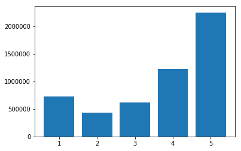

```python
plt.bar(range(1,6), [c[1], c[2], c[3], c[4], c[5]])
```

**In this project, we will predict whether a particular review gives 5 stars or not.**

The data set is fairly large with more than 5 million samples. To speed up the computations, we will use 500,000 samples for training, 10,000 for the dev-test set and 10,000 for the test set. To reduce any possible bias while partitioning the data set, we will first shuffle the data and then partition into training data, dev-test data, and test data using the following code:

```python
import random
random.seed(1234)
random.shuffle(all_data)
train_data, devtest_data, test_data = all_data[:500000], all_data[500000:510000], all_data[510000:520000]
```

## Step 1

The data are annotated with a star rating. In this project we will attempt to predict whether the review has 5 stars or not. In other words, we will use two categories: "it does not have 5 stars", and "it has 5 stars". According to these categories, check that the training data, devtest data and test data have the same proportions of the categories "it does not have 5 stars", and "it has 5 stars".

```python
def stars_cat (data_input, data_output):
    for x in data_input:
        if (x[1]==5):
            data_output.append((x[0], "it has 5 stars"))
        else:
            data_output.append((x[0], "it does not have 5 stars"))
    return

def count_5 (data_input):
    count = 0
    for x in data_input:
        if (x[1]=="it has 5 stars"):
            count = count + 1
    return count

def count_non_5 (data_input):
    count = 0
    for x in data_input:
        if (x[1]=="it does not have 5 stars"):
            count = count + 1
    return count
```

```python
train_data_x = []
devtest_data_x = []
test_data_x = []

stars_cat(train_data, train_data_x)
stars_cat(devtest_data, devtest_data_x)
stars_cat(test_data, test_data_x)
```

```python
print("Training Data")
print("it has 5 stars: "+str(count_5(train_data_x)/len(train_data_x)))
print("it does not have 5 stars: "+str(count_non_5(train_data_x)/len(train_data_x)))


print("\nDev-test Data")
print("it has 5 stars: "+str(count_5(devtest_data_x)/len(devtest_data_x)))
print("it does not have 5 stars: "+str(count_non_5(devtest_data_x)/len(devtest_data_x)))


print("\nTest Data")
print("it has 5 stars: "+str(count_5(test_data_x)/len(test_data_x)))
print("it does not have 5 stars: "+str(count_non_5(test_data_x)/len(test_data_x)))
```

```
Training Data
it has 5 stars: 0.42841
it does not have 5 stars: 0.57159

Dev-test Data
it has 5 stars: 0.4275
it does not have 5 stars: 0.5725

Test Data
it has 5 stars: 0.4324
it does not have 5 stars: 0.5676
```

# Step 2

Use sklearn to generate the tf.idf matrix of the training set. With this matrix, train an sklearn Naive Bayes classifier using the training set and report the F1 scores of the training set, the devtest set, and the set set.

```python
#TFIDF

from sklearn.feature_extraction.text import TfidfVectorizer
tfidf = TfidfVectorizer()

train_data_tfidf = tfidf.fit_transform([x for x, y in train_data_x])
devtest_data_tfidf = tfidf.transform([x for x, y in devtest_data_x])
test_data_tfidf = tfidf.transform([x for x, y in test_data_x])
```

```python
#Naive Bayes

from sklearn.naive_bayes import MultinomialNB

naive_bayes = MultinomialNB()

naive_bayes.fit(train_data_tfidf, [y for x, y in train_data_x])
```

```
MultinomialNB(alpha=1.0, class_prior=None, fit_prior=True)
```

```python
from sklearn.metrics import classification_report

predictions_train = naive_bayes.predict(train_data_tfidf)
predictions_devtest = naive_bayes.predict(devtest_data_tfidf)
predictions_test = naive_bayes.predict(test_data_tfidf)

print("Train Data")
print(classification_report([y for x, y in train_data_x], predictions_train))
print("\nDev-test Data")
print(classification_report([y for x, y in devtest_data_x], predictions_devtest))
print("\nTest Data")
print(classification_report([y for x, y in test_data_x], predictions_test))
```

```
Train Data
                          precision    recall  f1-score   support

it does not have 5 stars       0.77      0.93      0.84    285795
          it has 5 stars       0.87      0.63      0.73    214205

             avg / total       0.81      0.80      0.79    500000


Dev-test Data
                          precision    recall  f1-score   support

it does not have 5 stars       0.75      0.92      0.83      5725
          it has 5 stars       0.85      0.59      0.70      4275

             avg / total       0.79      0.78      0.77     10000


Test Data
                          precision    recall  f1-score   support

it does not have 5 stars       0.75      0.92      0.83      5676
          it has 5 stars       0.85      0.60      0.71      4324

             avg / total       0.80      0.78      0.78     10000
```

## Step 3

Logistic regression normally produces better results than Naive Bayes but it takes longer time to train. We can look at the [documentation of sklearn](http://scikit-learn.org/stable/modules/generated/sklearn.linear_model.LogisticRegression.html) and train a logistic regression classifier using the same tfidf information as in step 2. Report the F1 scores of the training set, the devtest set, and the test set.

```python
from sklearn.linear_model import LogisticRegression

logistic_reg = LogisticRegression()

logistic_reg.fit(train_data_tfidf, [y for x, y in train_data_x])
```

```
LogisticRegression(C=1.0, class_weight=None, dual=False, fit_intercept=True,
          intercept_scaling=1, max_iter=100, multi_class='ovr', n_jobs=1,
          penalty='l2', random_state=None, solver='liblinear', tol=0.0001,
          verbose=0, warm_start=False)
```

```python
pred_train =  logistic_reg.predict(train_data_tfidf)
pred_devtest =  logistic_reg.predict(devtest_data_tfidf)
pred_test =  logistic_reg.predict(test_data_tfidf)

print("Train Data")
print(classification_report([y for x, y in train_data_x], pred_train))
print("\nDev-test Data")
print(classification_report([y for x, y in devtest_data_x], pred_devtest))
print("\nTest Data")
print(classification_report([y for x, y in test_data_x], pred_test))
```

```
Train Data
                          precision    recall  f1-score   support

it does not have 5 stars       0.86      0.87      0.87    285795
          it has 5 stars       0.83      0.82      0.82    214205

             avg / total       0.85      0.85      0.85    500000


Dev-test Data
                          precision    recall  f1-score   support

it does not have 5 stars       0.85      0.86      0.85      5725
          it has 5 stars       0.81      0.79      0.80      4275

             avg / total       0.83      0.83      0.83     10000


Test Data
                          precision    recall  f1-score   support

it does not have 5 stars       0.85      0.87      0.86      5676
          it has 5 stars       0.82      0.80      0.81      4324

             avg / total       0.84      0.84      0.84     10000
```

## Step 4

A piece of code that counts the false positives and false negatives of the training set of each classifier.

```python
def calculate_fpfn(actual, predict):
    FP = 0
    FN = 0
    count = 0
    for x in actual:
        if x == "it does not have 5 stars" and predict[count] == "it has 5 stars":
            FP += 1
        if x == "it has 5 stars" and predict[count] == "it does not have 5 stars":
            FN += 1
        count += 1

    return(FP, FN)
```

```python
print("False Positive: "+str(calculate_fpfn([y for x,y in train_data_x], naive_bayes.predict(train_data_tfidf))[0]))
print("False Negative: "+str(calculate_fpfn([y for x,y in train_data_x], naive_bayes.predict(train_data_tfidf))[1]))
print()
print("False Positive: "+str(calculate_fpfn([y for x,y in train_data_x], logistic_reg.predict(train_data_tfidf))[0]))
print("False Negative: "+str(calculate_fpfn([y for x,y in train_data_x], logistic_reg.predict(train_data_tfidf))[1]))
```

```
False Positive: 20742
False Negative: 79299

False Positive: 35875
False Negative: 39162
```

**Logistic Regression predicts better than Naive Bayes. There is huge difference in terms of False Negative. Though in both case, the amount of False Negative is higher than the amount of False Positive. It's because in our Train-set, there are differences in ratio between positive and negative reviews. So the classifier is getting more biased towards one side.**

### Error Analysis

```python
error_count = 0
for x in range(0, len(devtest_data_x)-1):
    if (naive_bayes.predict(devtest_data_tfidf)[x]!=devtest_data_x[x][1]):
        error_count += 1
print("Number of errors: " +str(error_count))
print()
for x in range(0, 20):
    if (naive_bayes.predict(devtest_data_tfidf)[x]!=devtest_data_x[x][1]):
        print("Prediction: ")
        print(naive_bayes.predict(devtest_data_tfidf)[x])
        print()
        print("Actual: ")
        print(devtest_data_x[x][1])
        print(devtest_data_x[x][0])
        print()
        print('-----------------------------------------------------------')
        print()
```

```
Number of errors: 2183

Prediction:
it does not have 5 stars

Actual:
it has 5 stars
I went to B&R with two coworkers who were visiting from another country.  We shared some appetizers (Tartar, Brussel Sprouts, Trio of Crostini), we each ordered an entree and a dessert.  Overall, an excellent experience.  The food was very good and I loved the cocktails.

-----------------------------------------------------------

Prediction:
it does not have 5 stars

Actual:
it has 5 stars
Visited Monday 11\/9 because I had won a $20 gift certificate in a golf tournament.  Not knowing anything about the place, we were pleasantly surprised at the cleanliness of the bar\/restaurant.  There were a few people out on the patio (smokers, kind of a turnoff) but we were planning on sitting in…

-----------------------------------------------------------

Prediction:
it has 5 stars

Actual:
it does not have 5 stars
Fast, clean and gorgeous work done by friendly staff. If I lived in town, this would be my spot.

-----------------------------------------------------------

Prediction:
it does not have 5 stars

Actual:
it has 5 stars
We visited the Grand View buffet early in the evening, so it was not very crowded when we arrived. However, the dining room became quite busy later on. A buy-one-get-one free special was available on week days in January, making it quite affordable. We got two buffets for $20, along with nonalcoholi…

We were greeted upon arrival and were seated immediately. Our server was quite pleasant and efficient. She provided drink refills and cleared our table as needed. Employees at the various stations were also quite pleasant. They keep all food items well stocked throughout the evening. The view of the…

There were various food stations available, including Asian (with stir-fried items which you select and have prepared while you wait), Italian, American, and BBQ. A large salad bar offered a variety of fresh salad items, along with soups and rolls. A carving station offered deliciously tender prime …

```

[output cut: 15 more lines]

```

Actual:
it does not have 5 stars
My husband and I found this place through Groupon and are very glad we did!  We ordered some of the chef special rolls and they were phenomenal!  Really good.  Portions were big without overloading with rice!  We'll definately be going back!

-----------------------------------------------------------

Prediction:
it does not have 5 stars

Actual:
it has 5 stars
If you want REAL coffee and no watery a** Starbucks...go here! They have their own coffee plantation in Brazil I believe that they import from, so there is that. Amazing quality.

-----------------------------------------------------------
```

### Explanation of the Proposed New Classifier

**Improved classifier should clean the words list first, which will make the list more readable. Then there will be a list of bag of words, which will store all the vocabulary from the data set. Then we will train the new classifier with the bag of words. Then the classifier will predict from the base of bag of words. Hence, the clean more readable words instead of the whole sentence and the bag of words will bring better match and better prediction.Also, training the classifier with same ratio of positive and negative review will impore the prediction quality.**